# TimeSeriesAnalysis_Assignment4

2023-10-18

# Explain your model.

The dataset set shows the Retail sales of Beer, Wine, and Liquor Stores from January 2018 to July 2023. The sales are in millions of dollars over the period mentioned above.

The time series graph of this dataset shows the seasonality in sales every year. The sales values grow over the year, especially during the holiday season. The graph shows the spike highest during the year’s end and second highest during the month mid-year i.e., May and July. The graph shows a decline in sales at the beginning of the year.

Looking at the time series data it can also be inferred that there has been a visible increasing trend. Sales growth has been shown over the last 5 years. It has increased from 2018 to 2023.

```r
# Importing Excel file into data frame MyDf
library(readxl)
MyDf=read_excel("TimeSeriesData_LiquourSales.xls")
```

```r
# Change column names to readable form
colnames(MyDf) <- c("Date", "Sales")
```

```r
# Change date format from POSIXct to Date.
MyDf$Date <- as.Date(MyDf$Date)
```

```r
# To run the forecasting models in 'R', we need to convert the data into a time series.
library(fpp)
library(fpp2)
library(TTR)
```

```r
# Converting Data into timeseries.

Tsales <- ts(MyDf$Sales, start = c(2018,1), end = c(2023,7), frequency = 12)
```

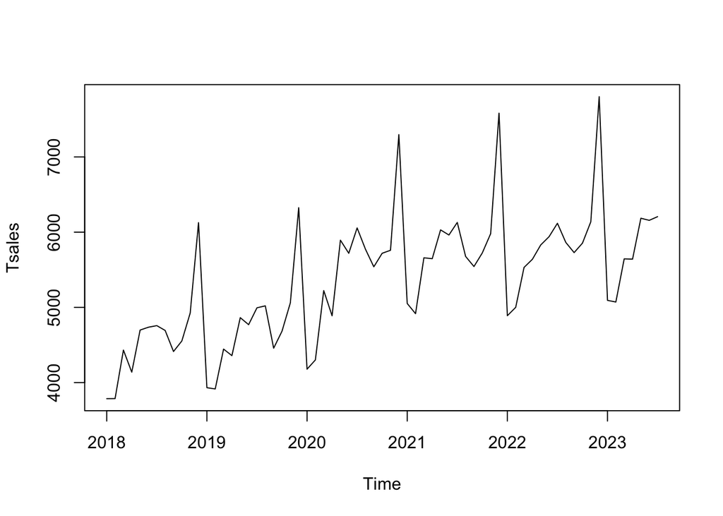

```r
plot(Tsales)
```

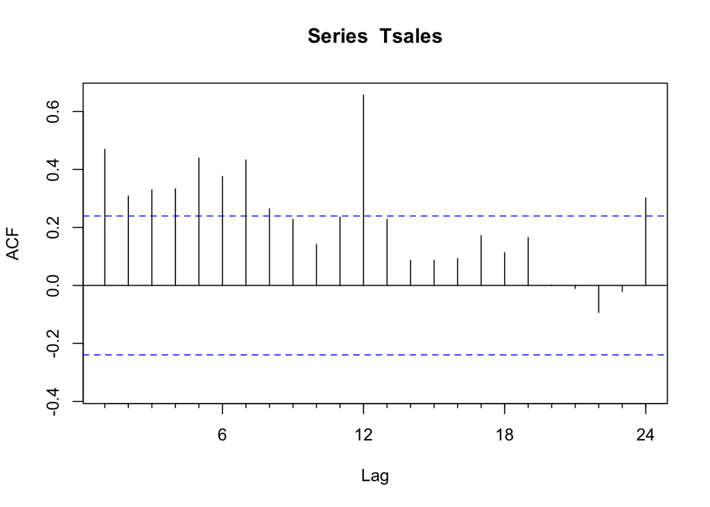

```r
Acf(Tsales)
```

## Naive Forecast:

The Naive forecasting method relies solely on the most recent data point to make predictions for future data points. It is a straightforward approach suitable for small datasets with minimal or no discernible trends or seasonality. However, in the context of the time series data provided in this assignment, the Naive method tends to produce an inaccurate result, as it may not capture complex patterns or underlying trends over a longer time.

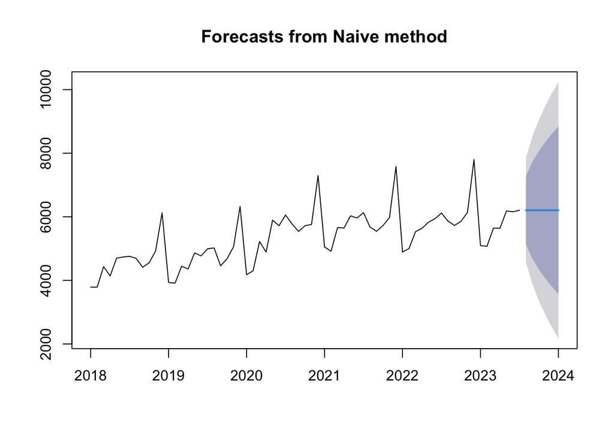

```r
naive_forecast <- naive(Tsales,6) # 6 is the forecasting period
plot(naive_forecast)
```

## Random Walk:

The Random Walk method is a simple forecasting technique that assumes that future values will be the same as the most recent observed value. In other words, it forecasts by repeating the last observed value for the specified number of periods. In the dataset, it is showing a similar result as the Naïve forecast which does not work for this dataset.

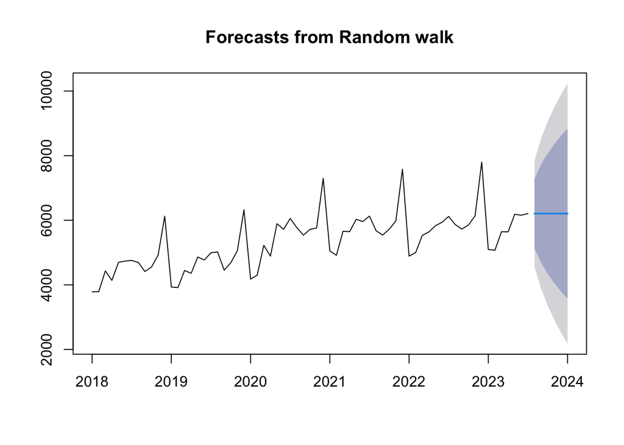

```r
rwf_forecast <- rwf(Tsales,6)
plot(rwf_forecast)
```

```r
summary(rwf_forecast)
```

```
##
## Forecast method: Random walk
##
## Model Information:
## Call: rwf(y = Tsales, h = 6)
##
## Residual sd: 839.6231
##
## Error measures:
##                    ME     RMSE      MAE        MPE     MAPE     MASE       ACF1
## Training set 36.66667 839.6231 511.1212 -0.4072291 9.680379 1.597617 -0.3735751
##
## Forecasts:
##          Point Forecast    Lo 80    Hi 80    Lo 95     Hi 95
## Aug 2023           6206 5129.980 7282.020 4560.369  7851.631
## Sep 2023           6206 4684.277 7727.723 3878.726  8533.274
## Oct 2023           6206 4342.278 8069.722 3355.683  9056.317
## Nov 2023           6206 4053.959 8358.041 2914.738  9497.262
## Dec 2023           6206 3799.945 8612.055 2526.257  9885.743
## Jan 2024           6206 3570.299 8841.701 2175.043 10236.957
```

## Random walk with a drift:

This method considers the most recent data point with a drift term and hence can provide good results for a short time period. In this case, this is not capturing the seasonality but showing a trend over time.

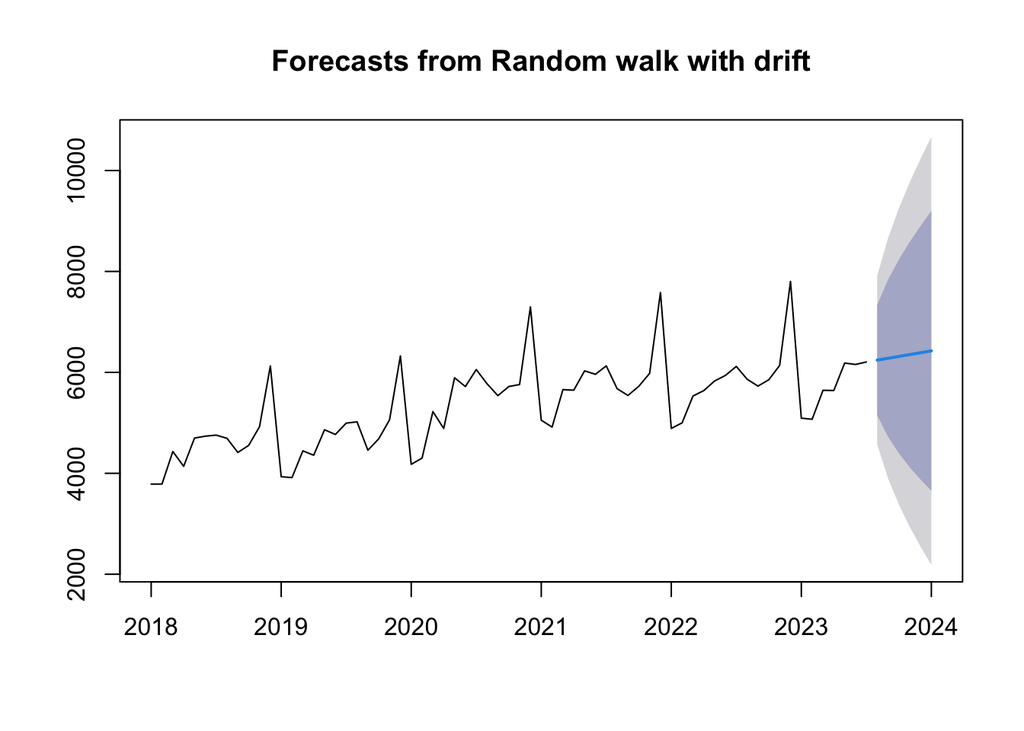

```r
rwf_forecast1 <- rwf(Tsales,6, drift=TRUE)
plot(rwf_forecast1)
```

# Seasonal Naive:

Seasonal data exhibits a repeating pattern or seasonality, typically occurring at regular intervals annually. For example, sales data increases during holidays. This captures the accurate result for the provided dataset with high seasonality.

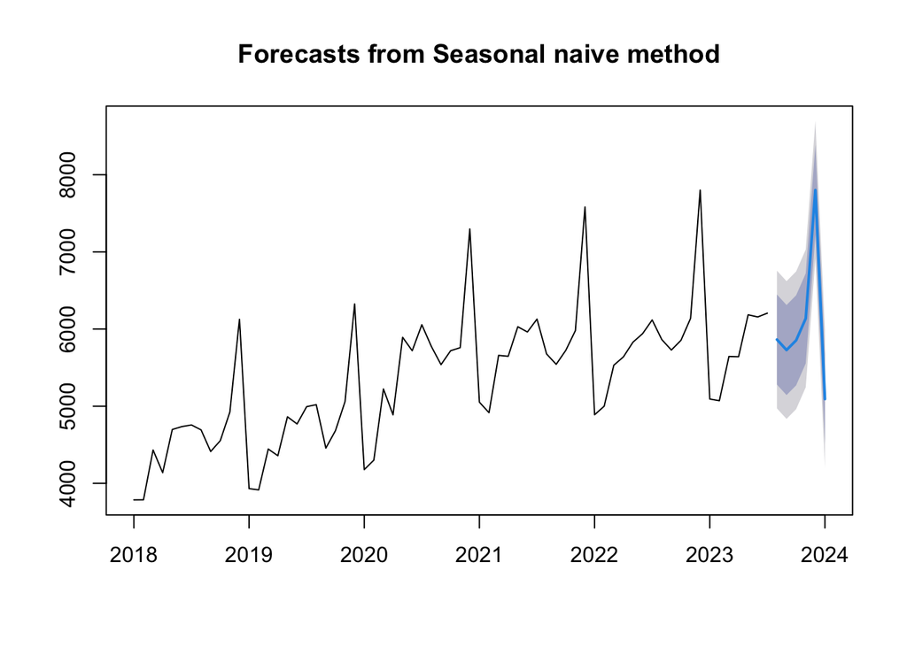

```r
snaive_forecast <- snaive(Tsales,6)
plot(snaive_forecast)
```

```r
summary(snaive_forecast)
```

```
##
## Forecast method: Seasonal naive method
##
## Model Information:
## Call: snaive(y = Tsales, h = 6)
##
## Residual sd: 455.3739
##
## Error measures:
##                    ME     RMSE      MAE      MPE     MAPE MASE     ACF1
## Training set 297.0909 455.3739 319.9273 5.347936 5.764731    1 0.805925
##
## Forecasts:
##          Point Forecast    Lo 80    Hi 80    Lo 95    Hi 95
## Aug 2023           5864 5280.415 6447.585 4971.484 6756.516
## Sep 2023           5728 5144.415 6311.585 4835.484 6620.516
## Oct 2023           5854 5270.415 6437.585 4961.484 6746.516
## Nov 2023           6138 5554.415 6721.585 5245.484 7030.516
## Dec 2023           7801 7217.415 8384.585 6908.484 8693.516
## Jan 2024           5093 4509.415 5676.585 4200.484 5985.516
```

## Exponential smoothing

### ETS Forecasting

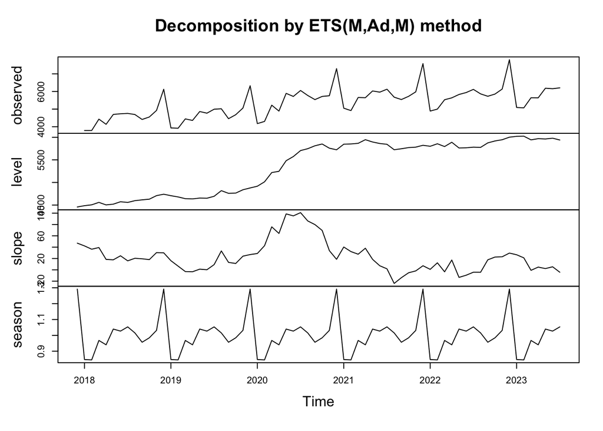

```r
#Exponential
ets_forecasting <- ets(Tsales)
plot(ets_forecasting)
```

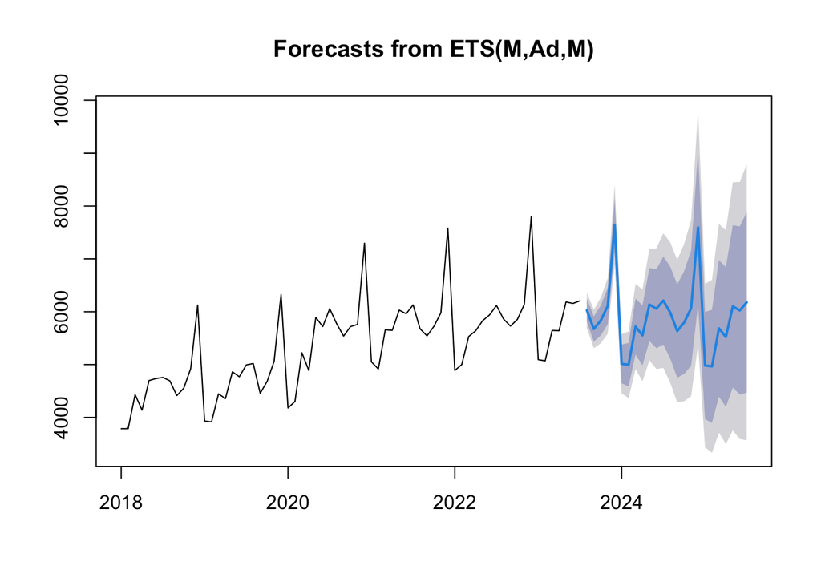

```r
Forecast_ETS=forecast(ets_forecasting)
plot(Forecast_ETS)
```

## Holt Winters

### Holt-Winters:

Holt-Winters is a triple exponential smoothing method that considers three main components: level (the current value of the series), trend (the direction in which the series is moving), and seasonality (repeating patterns within the data). This is particularly useful in this dataset which deals with time series data that exhibit trend and seasonality.

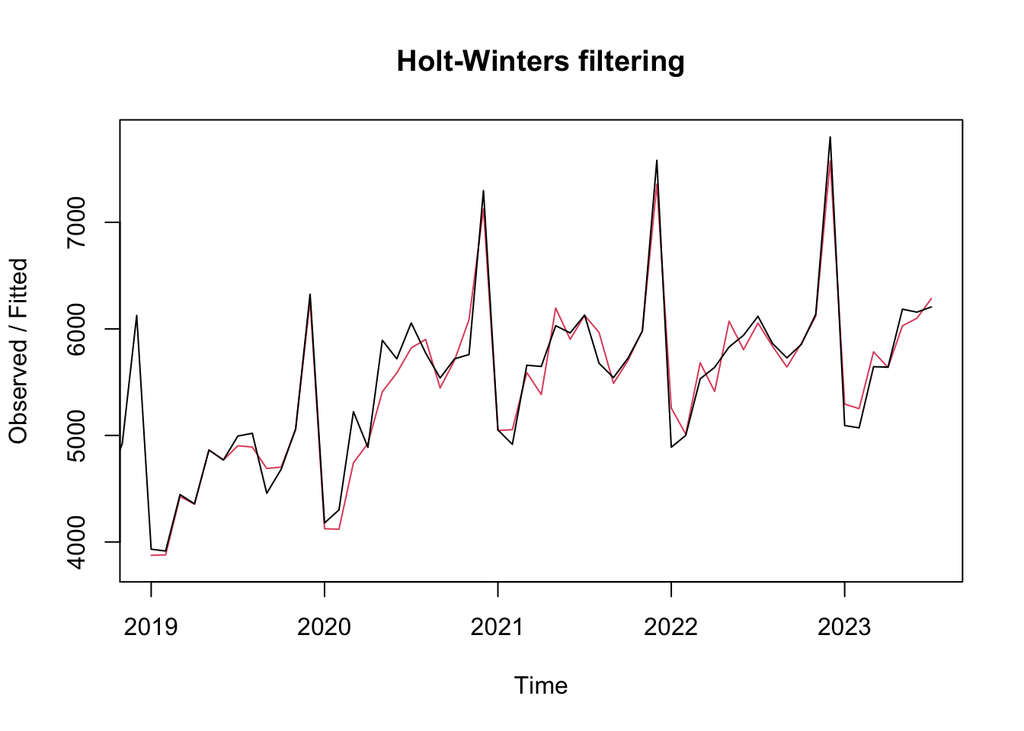

```r
HW<- HoltWinters(Tsales)
plot(HW)
```

```r
HW_forecast<-forecast(HW, h=6)
summary(HW_forecast)
```

```
##
## Forecast method: HoltWinters
##
## Model Information:
## Holt-Winters exponential smoothing with trend and additive seasonal component.
##
## Call:
## HoltWinters(x = Tsales)
##
## Smoothing parameters:
##  alpha: 0.5582949
##  beta : 0
##  gamma: 0.6938889
##
## Coefficients:
##           [,1]
## a   5945.77223
## b     12.59921
## s1    18.97336
## s2  -185.94834
## s3   -54.41296
## s4   202.98244
## s5  1699.91458
## s6  -850.94117
## s7  -787.70931
## s8  -153.79223
## s9  -191.93399
## s10  231.80565
## s11  172.57570
## s12  270.76448
##
## Error measures:
##                    ME     RMSE      MAE       MPE     MAPE      MASE       ACF1
## Training set 22.08424 168.4474 121.0668 0.3251525 2.181053 0.3784198 -0.1306528
##
## Forecasts:
##          Point Forecast    Lo 80    Hi 80    Lo 95    Hi 95
## Aug 2023       5977.345 5761.362 6193.328 5647.027 6307.663
## Sep 2023       5785.022 5537.659 6032.386 5406.712 6163.332
## Oct 2023       5929.157 5653.968 6204.346 5508.292 6350.022
## Nov 2023       6199.152 5898.704 6499.599 5739.656 6658.647
## Dec 2023       7708.683 7384.941 8032.425 7213.562 8203.804
## Jan 2024       5170.426 4824.957 5515.896 4642.076 5698.776
```

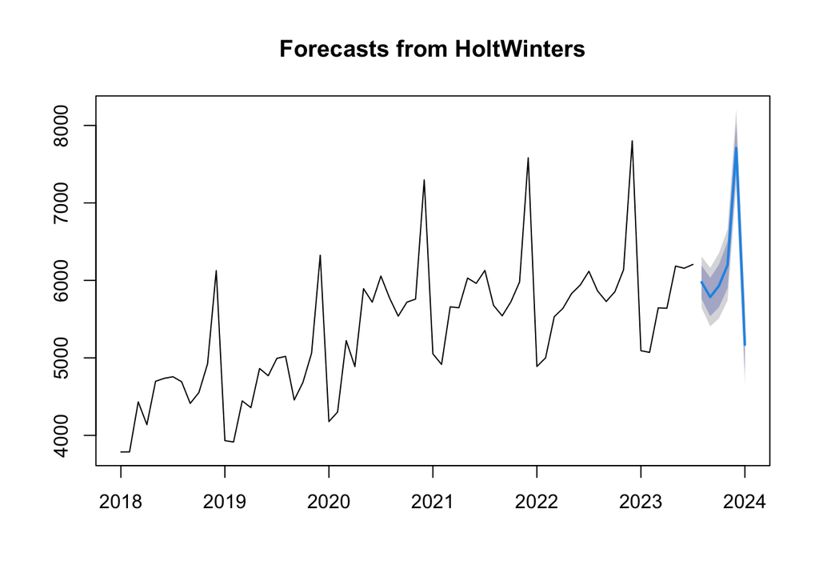

```r
plot(HW_forecast)
```

## Average Methods

### Take Mean of all available history

### Mean Forecast:

Mean Forecasting predicts future values by taking historical observations’ average (mean). In this case, the forecasted values for the next 6 periods will be calculated as the average of the historical values in the Tsales data. It calculates the mean of the observed values in the time series, which is irrelevant to predicting future values as this data set has seasonality and trend.

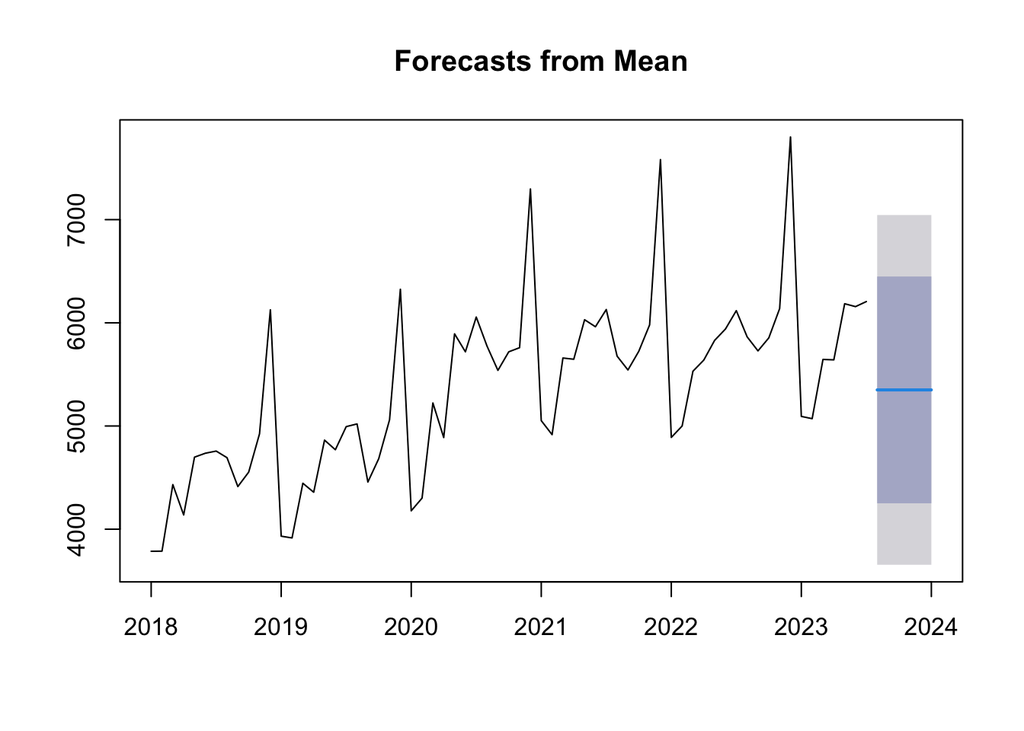

```r
mean_forecast <- meanf(Tsales,6) # 6 is the forecasting period
plot(mean_forecast)
```

```r
summary(mean_forecast)
```

```
##
## Forecast method: Mean
##
## Model Information:
## $mu
## [1] 5349.866
##
## $mu.se
## [1] 102.939
##
## $sd
## [1] 842.5921
##
## $bootstrap
## [1] FALSE
##
## $call
## meanf(y = Tsales, h = 6)
##
## attr(,"class")
## [1] "meanf"
##
## Error measures:
##                         ME     RMSE      MAE       MPE     MAPE     MASE
## Training set -6.549719e-13 836.2805 691.6627 -2.472076 13.37699 2.161937
##                   ACF1
## Training set 0.4695992
##
## Forecasts:
##          Point Forecast    Lo 80   Hi 80    Lo 95    Hi 95
## Aug 2023       5349.866 4251.012 6448.72 3655.068 7044.663
## Sep 2023       5349.866 4251.012 6448.72 3655.068 7044.663
## Oct 2023       5349.866 4251.012 6448.72 3655.068 7044.663
## Nov 2023       5349.866 4251.012 6448.72 3655.068 7044.663
## Dec 2023       5349.866 4251.012 6448.72 3655.068 7044.663
## Jan 2024       5349.866 4251.012 6448.72 3655.068 7044.663
```

### Moving Averages:

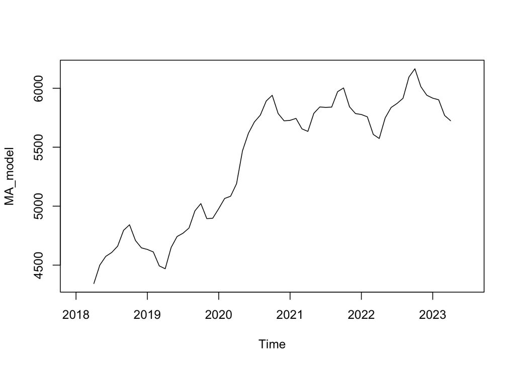

```r
MA_model <- ma(Tsales,order=6)
plot(MA_model)
```

```r
MA_forecast <- forecast(MA_model, 6)
```

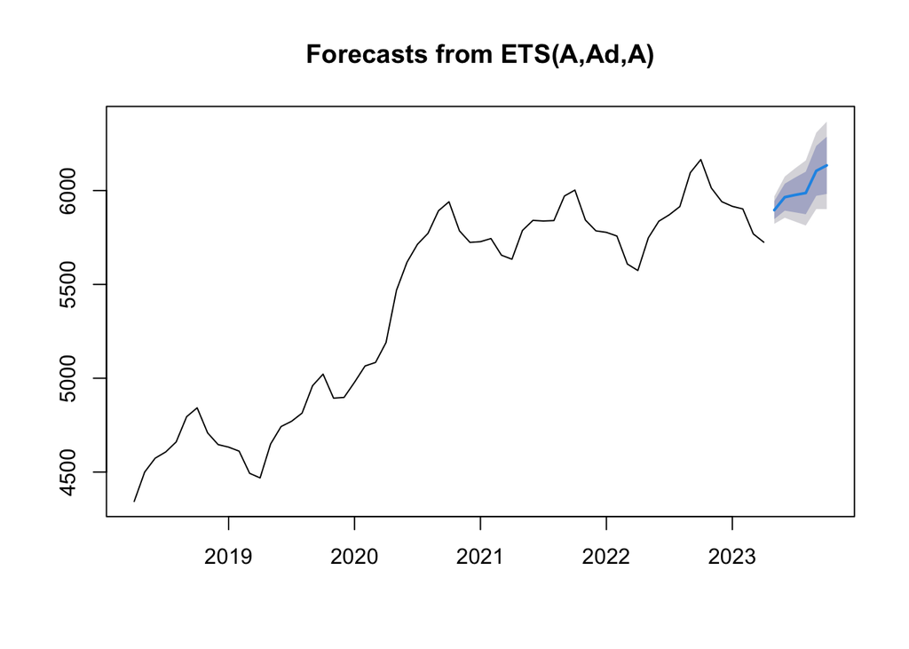

```r
plot(MA_forecast)
```

## SSE Simple

#### Applies the Holt-Winters exponential smoothing method to this time series data with specific settings for the smoothing parameters.

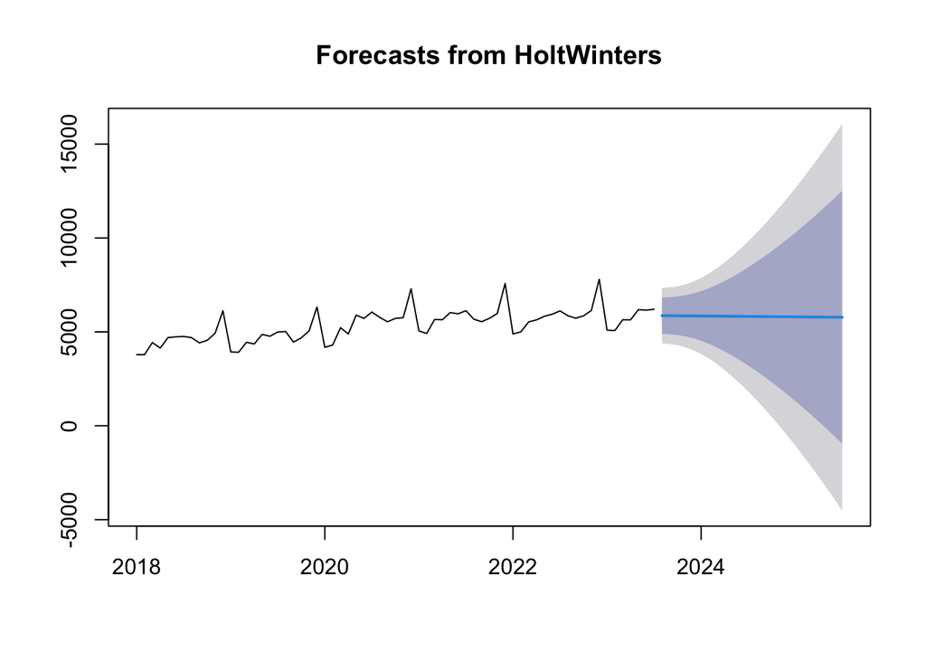

```r
### beta=TRUE: It means the model includes a trend component. This implies that the Holt-Winters model will consider the presence of a linear trend in the data, allowing it to capture both the level (average value) and the direction (increase or decrease) of the data over time.

### gamma=FALSE: When gamma=FALSE, the model does not include a seasonality component. It assumes that the data does not exhibit any repeating patterns or seasonality, and the model focuses solely on the trend and level components.

SSE_Simple <- HoltWinters(Tsales,beta=TRUE,gamma=FALSE)
SSE_Forecast<-forecast(SSE_Simple)
plot(SSE_Forecast)
```

```r
summary(SSE_Forecast)
```

```
##
## Forecast method: HoltWinters
##
## Model Information:
## Holt-Winters exponential smoothing with trend and without seasonal component.
##
## Call:
## HoltWinters(x = Tsales, beta = TRUE, gamma = FALSE)
##
## Smoothing parameters:
##  alpha: 0.09852451
##  beta : TRUE
##  gamma: FALSE
##
## Coefficients:
##          [,1]
## a 5869.258917
## b   -3.807777
##
## Error measures:
##                      ME     RMSE      MAE       MPE    MAPE     MASE      ACF1
## Training set -0.7507349 748.3193 581.0608 -1.204463 11.0221 1.816228 0.2066049
##
## Forecasts:
##          Point Forecast     Lo 80     Hi 80       Lo 95     Hi 95
## Aug 2023       5865.451 4898.9787  6831.924  4387.35908  7343.543
## Sep 2023       5861.643 4876.5863  6846.700  4355.12866  7368.158
## Oct 2023       5857.836 4832.1938  6883.477  4289.25184  7426.419
## Nov 2023       5854.028 4759.9463  6948.109  4180.77452  7527.281
## Dec 2023       5850.220 4657.0346  7043.405  4025.40042  7675.040
## Jan 2024       5846.412 4523.4964  7169.328  3823.18704  7869.637
## Feb 2024       5842.604 4361.2560  7323.953  3577.07744  8108.132
## Mar 2024       5838.797 4173.0576  7504.536  3291.26864  8386.325
## Apr 2024       5834.989 3961.7243  7708.254  2970.07794  8699.900
## May 2024       5831.181 3729.7939  7932.568  2617.38664  9044.976
## Jun 2024       5827.373 3479.4071  8175.340  2236.46890  9418.278
## Jul 2024       5823.566 3212.3197  8434.812  1830.00960  9817.122
## Aug 2024       5819.758 2929.9582  8709.557  1400.19063 10239.325
## Sep 2024       5815.950 2633.4840  8998.416   948.78823 10683.112
## Oct 2024       5812.142 2323.8499  9300.435   477.25947 11147.025
## Nov 2024       5808.334 2001.8457  9614.823   -13.18768 11629.857
## Dec 2024       5804.527 1668.1342  9940.919  -521.53978 12130.593
## Jan 2025       5800.719 1323.2779 10278.160 -1046.93615 12648.374
## Feb 2025       5796.911  967.7607 10626.062 -1588.63718 13182.460
## Mar 2025       5793.103  602.0026 10984.204 -2146.00015 13732.207
## Apr 2025       5789.296  226.3728 11352.218 -2718.46069 14297.052
## May 2025       5785.488 -158.8017 11729.777 -3305.51851 14876.494
## Jun 2025       5781.680 -553.2284 12116.588 -3906.72629 15470.086
## Jul 2025       5777.872 -956.6436 12512.388 -4521.68092 16077.425
```

```r
SSE_Simple$SSE
```

```
## [1] 36398811
```

```r
head(SSE_Simple$fitted)
```

```
##              xhat    level     trend
## Mar 2018 3788.000 3787.000   1.00000
## Apr 2018 3915.900 3851.450  64.44979
## May 2018 4024.114 3937.782  86.33212
## Jun 2018 4243.235 4090.508 152.72641
## Jul 2018 4493.060 4291.784 201.27587
## Aug 2018 4746.345 4519.065 227.28042
```

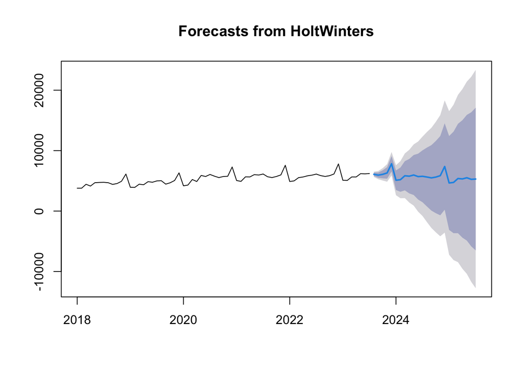

```r
# beta=TRUE:It means that the model includes a trend component. This means that the Holt-Winters model considers the presence of a linear trend in the data, allowing it to capture both the level (average value) and the direction (increase or decrease) of the data over time.

# gamma=TRUE:It indicates that the model includes a seasonality component. This implies that the Holt-Winters model takes into account repeating patterns or seasonality in the data, such as monthly or yearly cycles.

SSE_Simple1 <- HoltWinters(Tsales,beta=TRUE,gamma=TRUE)
SSE_Forecast1<-forecast(SSE_Simple1)
plot(SSE_Forecast1)
```

```r
summary(SSE_Forecast1)
```

```
##
## Forecast method: HoltWinters
##
## Model Information:
## Holt-Winters exponential smoothing with trend and additive seasonal component.
##
## Call:
## HoltWinters(x = Tsales, beta = TRUE, gamma = TRUE)
##
## Smoothing parameters:
##  alpha: 0.5870371
##  beta : TRUE
##  gamma: TRUE
##
## Coefficients:
##            [,1]
## a   6212.827009
## b    -37.783538
## s1   -91.530394
## s2  -192.815668
## s3   -22.041140
## s4   246.751470
## s5  1802.177333
## s6  -883.358613
## s7  -754.970432
## s8   -69.659587
## s9  -101.474201
## s10  131.916042
## s11  -93.610547
## s12   -6.827009
##
## Error measures:
##                     ME     RMSE      MAE        MPE     MAPE      MASE
## Training set -1.560464 221.6451 167.7709 -0.1001112 3.023347 0.5244033
##                    ACF1
## Training set -0.2770186
##
## Forecasts:
##          Point Forecast       Lo 80     Hi 80       Lo 95     Hi 95
## Aug 2023       6083.513  5796.85257  6370.174   5645.1037  6521.922
```

[output cut: 8 more lines]

```
## May 2024       5966.908  2656.86342  9276.952    904.6318 11029.184
## Jun 2024       5703.598  1911.11754  9496.078    -96.5001 11503.695
## Jul 2024       5752.598  1456.00161 10049.193   -818.4789 12323.674
## Aug 2024       5630.111   753.79164 10506.430  -1827.5757 13087.797
## Sep 2024       5491.042    75.42834 10906.655  -2791.4243 13773.508
## Oct 2024       5624.033  -350.95522 11599.021  -3513.9228 14761.988
## Nov 2024       5855.042  -698.58010 12408.664  -4167.8580 15877.942
## Dec 2024       7372.684   221.88402 14523.484  -3563.5209 18308.889
## Jan 2025       4649.365 -3116.52643 12415.256  -7227.5409 16526.270
## Feb 2025       4739.969 -3658.36164 13138.300  -8104.1695 17584.108
## Mar 2025       5387.497 -3660.11488 14435.108  -8449.6311 19224.624
## Apr 2025       5317.899 -4395.37258 15031.170  -9537.2677 20173.065
## May 2025       5513.505 -4881.38207 15908.392 -10384.1030 21411.113
## Jun 2025       5250.195 -5841.87644 16342.267 -11713.6644 22214.055
## Jul 2025       5299.195 -6505.26927 17103.659 -12754.1752 23352.565
```

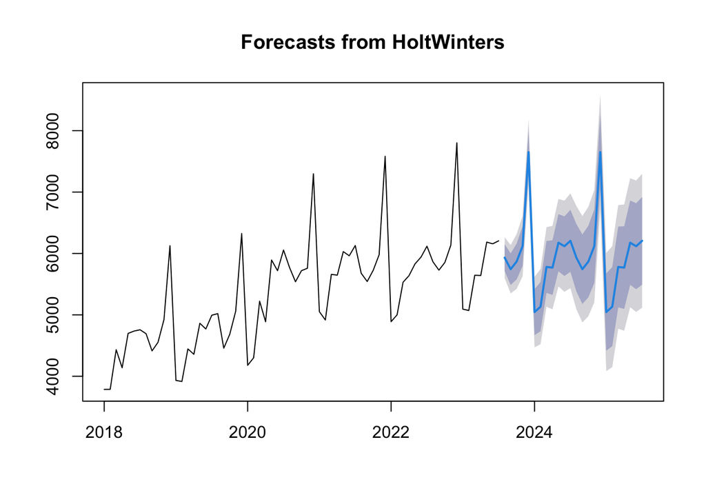

```r
# beta=FALSE: Setting beta=FALSE means that the model does not include a trend component. This implies that the Holt-Winters model assumes that the data does not exhibit a linear trend over time and focuses solely on capturing seasonality and the level (average value) of the data.

# gamma=TRUE: The model includes a seasonality component. It indicates that the Holt-Winters model considers the presence of repeating patterns or seasonality in the data, such as monthly or yearly cycles.

SSE_Simple2 <- HoltWinters(Tsales,beta=FALSE,gamma=TRUE)
SSE_Forecast2<-forecast(SSE_Simple2)
plot(SSE_Forecast2)
```

```r
summary(SSE_Forecast2)
```

```
##
## Forecast method: HoltWinters
##
## Model Information:
## Holt-Winters exponential smoothing without trend and with additive seasonal component.
##
## Call:
## HoltWinters(x = Tsales, beta = FALSE, gamma = TRUE)
##
## Smoothing parameters:
##  alpha: 0.6291472
##  beta : FALSE
##  gamma: TRUE
##
## Coefficients:
##           [,1]
## a   5896.70449
## s1    34.73622
## s2  -153.26307
## s3   -29.28965
## s4   222.96377
## s5  1753.94256
## s6  -851.11149
## s7  -763.80014
## s8  -116.50218
## s9  -127.11742
## s10  278.36786
## s11  221.04237
## s12  309.29551
##
## Error measures:
##                    ME     RMSE      MAE       MPE     MAPE      MASE       ACF1
## Training set 38.20503 172.7834 131.0016 0.6246225 2.363931 0.4094729 -0.1994082
##
## Forecasts:
##          Point Forecast    Lo 80    Hi 80    Lo 95    Hi 95
## Aug 2023       5931.441 5713.500 6149.381 5598.130 6264.752
## Sep 2023       5743.441 5485.956 6000.927 5349.651 6137.232
## Oct 2023       5867.415 5575.696 6159.134 5421.270 6313.560
## Nov 2023       6119.668 5797.332 6442.005 5626.697 6612.639
## Dec 2023       7650.647 7300.359 8000.935 7114.928 8186.366
## Jan 2024       5045.593 4669.425 5421.761 4470.293 5620.893
## Feb 2024       5132.904 4732.525 5533.284 4520.577 5745.232
## Mar 2024       5780.202 5356.995 6203.410 5132.962 6427.442
## Apr 2024       5769.587 5324.721 6214.453 5089.224 6449.950
## May 2024       6175.072 5709.555 6640.590 5463.125 6887.020
## Jun 2024       6117.747 5632.456 6603.038 5375.558 6859.935
## Jul 2024       6206.000 5701.710 6710.290 5434.755 6977.245
## Aug 2024       5931.441 5382.072 6480.810 5091.253 6771.628
## Sep 2024       5743.441 5177.220 6309.663 4877.480 6609.403
## Oct 2024       5867.415 5284.827 6450.002 4976.424 6758.405
## Nov 2024       6119.668 5521.163 6718.174 5204.333 7035.004
## Dec 2024       7650.647 7036.636 8264.658 6711.598 8589.696
## Jan 2025       5045.593 4416.458 5674.728 4083.414 6007.772
## Feb 2025       5132.904 4489.001 5776.808 4148.139 6117.670
## Mar 2025       5780.202 5121.861 6438.543 4773.357 6787.048
## Apr 2025       5769.587 5097.119 6442.055 4741.135 6798.039
## May 2025       6175.072 5488.767 6861.377 5125.459 7224.685
## Jun 2025       6117.747 5417.879 6817.615 5047.391 7188.103
## Jul 2025       6206.000 5492.826 6919.174 5115.295 7296.705
```

## Plot the time series and different model forecasts in one chart

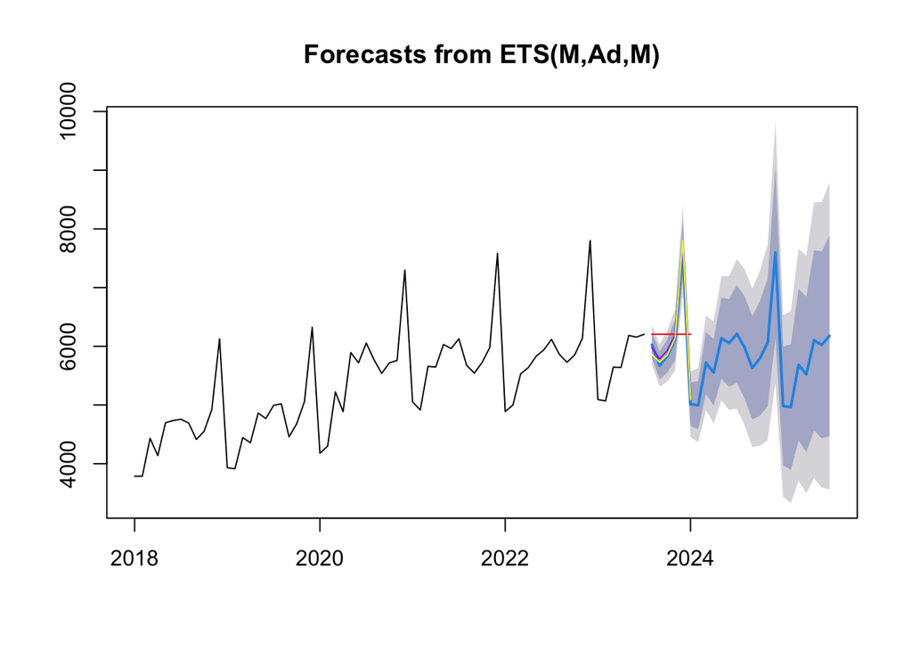

```r
plot(Forecast_ETS)
lines(HW_forecast$mean,col="purple")
lines(naive_forecast$mean,col="purple")
lines(rwf_forecast$mean,col="red")
lines(snaive_forecast$mean,col="yellow")
lines(ets_forecasting$mean,col="blue")
lines(SSE_Simple$mean,col="green")
lines(SSE_Simple1$mean,col="cyan")
lines(SSE_Simple2$mean,col="brown")
```

## Pick an accuracy measure, compare your models, and state the best model based on the accuracy comparison

### Accuracy Measure Selected for Model Comparison:Mean Absolute Percentage Error (MAPE):

#### The Mean Absolute Percentage Error (MAPE)

It quantifies the average forecast errors in terms of percentages. It is a valuable accuracy metric because it provides a percentage-based understanding of forecast accuracy that is easily comprehensible to a wide audience. For instance, a MAPE of 3% signifies a 3% disparity between the actual and forecasted data. Generally, a lower MAPE indicates a higher level of accuracy in forecasting.

### MAPE for different Models:

● Mean Forecast: 13.37699

● Naive Forecast: 9.680379

● Random Walk Forecast: 9.680379

● Random Walk Forecast with Drift: 9.606246

● Simple Naive Forecast: 5.764731

● Exponential smoothing Forecast: 1.826156

● Holt-Winter Forecast: 2.181053

● SSE Simple Forecast: 11.0221

● SSE Simple Forecast1: 3.023347

● SSE Simple Forecast2: 2.363931

```r
accuracy(naive_forecast)
```

```
##                    ME     RMSE      MAE        MPE     MAPE     MASE       ACF1
## Training set 36.66667 839.6231 511.1212 -0.4072291 9.680379 1.597617 -0.3735751
```

```r
accuracy(mean_forecast)
```

```
##                         ME     RMSE      MAE       MPE     MAPE     MASE
## Training set -6.549719e-13 836.2805 691.6627 -2.472076 13.37699 2.161937
##                   ACF1
## Training set 0.4695992
```

```r
accuracy(rwf_forecast)
```

```
##                    ME     RMSE      MAE        MPE     MAPE     MASE       ACF1
## Training set 36.66667 839.6231 511.1212 -0.4072291 9.680379 1.597617 -0.3735751
```

```r
accuracy(rwf_forecast1)
```

```
##                         ME     RMSE      MAE       MPE     MAPE     MASE
## Training set -2.759543e-13 838.8221 505.2222 -1.105515 9.606246 1.579178
##                    ACF1
## Training set -0.3735751
```

```r
accuracy(snaive_forecast)
```

```
##                    ME     RMSE      MAE      MPE     MAPE MASE     ACF1
## Training set 297.0909 455.3739 319.9273 5.347936 5.764731    1 0.805925
```

```r
accuracy(HW_forecast)
```

```
##                    ME     RMSE      MAE       MPE     MAPE      MASE       ACF1
## Training set 22.08424 168.4474 121.0668 0.3251525 2.181053 0.3784198 -0.1306528
```

```r
accuracy(Forecast_ETS)
```

```
##                     ME     RMSE      MAE         MPE     MAPE      MASE
## Training set -1.200088 131.5137 97.78264 -0.04642159 1.826156 0.3056402
##                     ACF1
## Training set -0.09527194
```

```r
accuracy(SSE_Forecast)
```

```
##                      ME     RMSE      MAE       MPE    MAPE     MASE      ACF1
## Training set -0.7507349 748.3193 581.0608 -1.204463 11.0221 1.816228 0.2066049
```

```r
accuracy(SSE_Forecast1)
```

```
##                     ME     RMSE      MAE        MPE     MAPE      MASE
## Training set -1.560464 221.6451 167.7709 -0.1001112 3.023347 0.5244033
##                    ACF1
## Training set -0.2770186
```

```r
accuracy(SSE_Forecast2)
```

```
##                    ME     RMSE      MAE       MPE     MAPE      MASE       ACF1
## Training set 38.20503 172.7834 131.0016 0.6246225 2.363931 0.4094729 -0.1994082
```

### Pick the best model:

Looking at the MAPE for all the models the best models to use for forecasting are: 1. Exponential Smoothing Forecast 2. Holt-Winters Forecast

[output not shown]